# DA - Final Project Report

Monish Raj Raghu and Mouad Ait Taleb Ali

5th Aug 2022

# Project Report

## Contributors

1. Monish Raj Raghu (mailto:monishraj@vt.edu) (Worked on Logistic Regression and Trees-based algorithms)
2. Mouad Ait Taleb Ali (mailto:mouad@vt.edu) (Worked on SVM and EDA)

```r
library(hdrm)
downloadData(Golub1999)
attachData(Golub1999)
library(tree)
library(ISLR)
library(randomForest)
library(e1071)
```

## Dataset Overview

[output not shown]

```r
set.seed(1)

n = nrow(X)
# Split data into train and test sets
train_rows <- sample(1:n, n/2)
X.train <- X[train_rows, ]
X.test <- X[-train_rows, ]

y.train <- y[train_rows]
y.test <- y[-train_rows]

y.train = as.numeric(y.train) - 1
y.test = as.numeric(y.test)-1
traindata = data.frame(x  = X.train, y = as.factor(y.train))
testdata <- data.frame(z  = X.test, w = as.factor(y.test))
dim(X)
```

```
## [1]   72 7129
```

```r
dim(X.train)
```

```
## [1]   36 7129
```

```r
dim(X.test)
```

```
## [1]   36 7129
```

```r
length(y.train)
```

```
## [1] 36
```

```r
length(y.test)
```

```
## [1] 36
```

```r
dim(testdata)
```

```
## [1]   36 7130
```

```
 Basically, the golub1999 data set is a large matrix with 72 rows and 7129 columns, after the partition, we obtain a training data set with 36 rows and 7129 columns,  based on the training data set, we've been able to generate all necessary models.
```

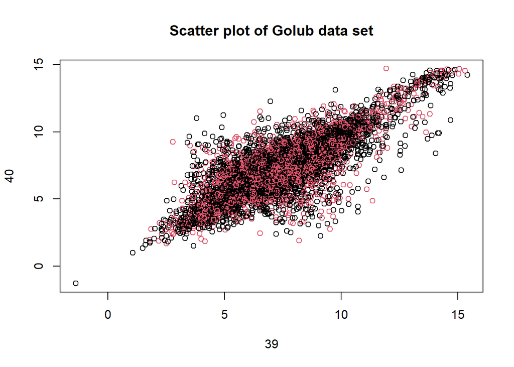

```r
plot(t(X), col= y, main="Scatter plot of Golub data set")
```

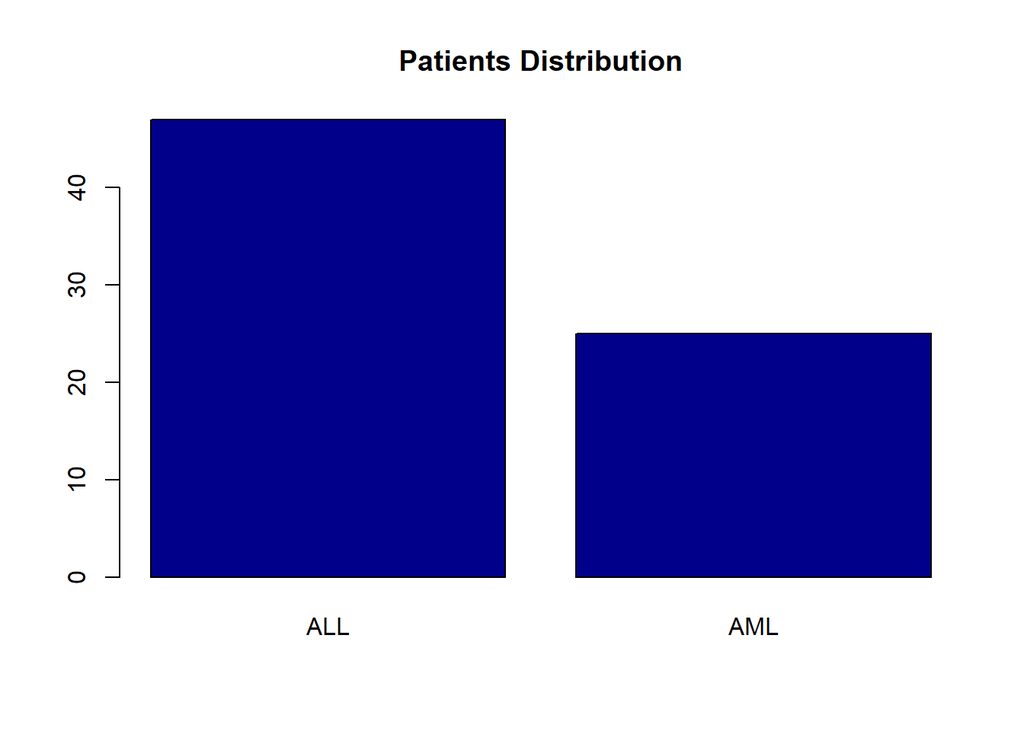

```r
plot(y, col = "darkblue", main="Patients Distribution")
```

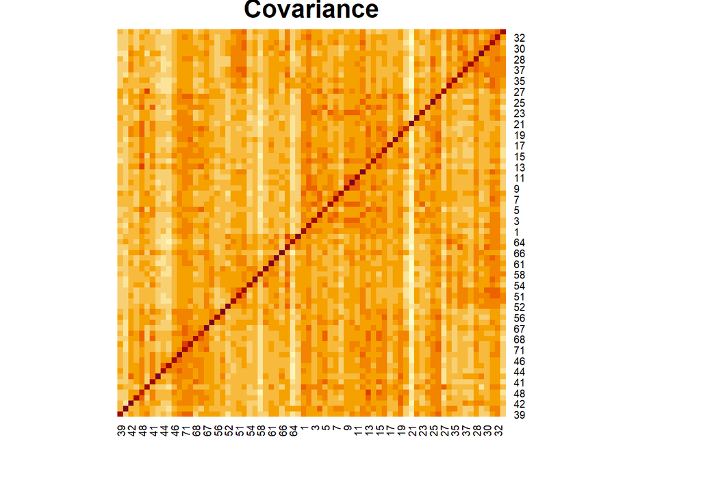

```r
heatmap(cov(t(X)),Rowv = NA, Colv = NA,  main = "Covariance")
```

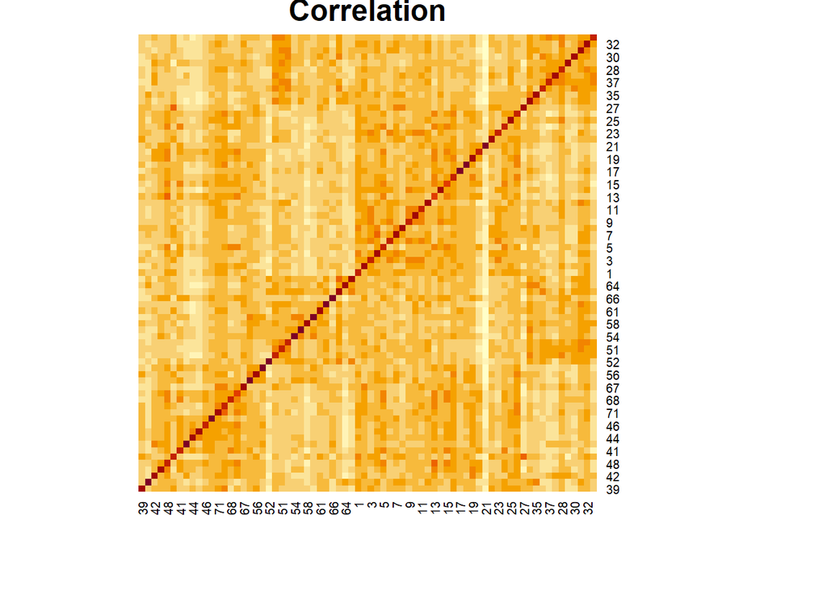

```
As you can see most of the figures show an exciting linear relationship among the Golub data set, which the Correlation and Covariance heatmap clearly indicates. In addition, the scatter plot of the transposed data also confirms the same pattern.

On the other hand, the histogram figure shows the distribution of the acute lymphoblastic leukemia (ALL) and acute myeloid leukemia (AML) diseases among the patients.

To further investigate the data set, we ran multiple sparse classification methods that would allow us to generate and compare their models and ultimately pick the best possible model.
```

```r
heatmap(cor(t(X)),Rowv = NA, Colv = NA, main = "Correlation")
```

## Logistic Regression

```r
set.seed(1)

n = nrow(X)
# Split data into train and test sets
train_rows <- sample(1:n, n/2)
X.train <- X[train_rows, ]
X.test <- X[-train_rows, ]

y.train <- y[train_rows]
y.test <- y[-train_rows]

dim(X.train)
```

```
## [1]   36 7129
```

Logistic regression is not ideal in a p>>n setting. The weight estimates is usually skewed leading to an over-fitted model. Let’s use regularization methods to help us with the overfitting problems.

```r
lasso.mod = glmnet(X.train, y.train, alpha=1, family=binomial)
cv.out <- cv.glmnet(X.train, y.train, alpha=1, family=binomial)
```

We use lasso for our regression. We use the package glmnet where altering the value of alpha and setting it equal to 1 gives us the model with lasso regression.

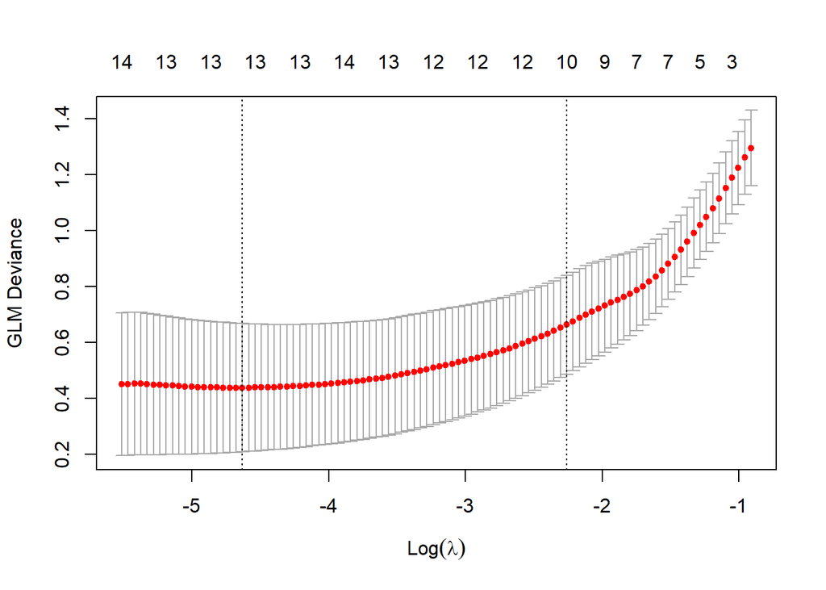

```r
plot(cv.out)
```

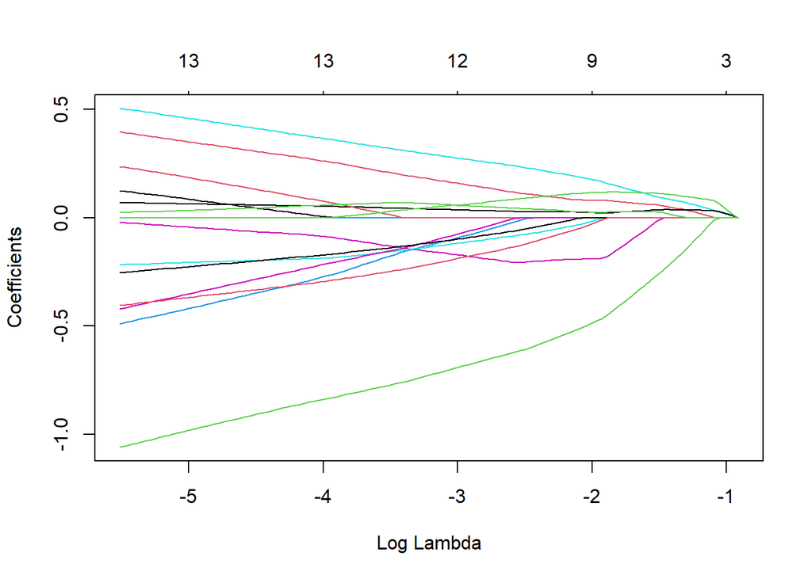

```r
fit_plot <- cv.out$glmnet.fit

plot(fit_plot, xvar="lambda")
```

Lasso regularization does both shrinkage and variable selection.

```r
y.test = as.numeric(y.test)-1

bestLambda_lasso_reg = cv.out$lambda.min
lasso.pred = predict(lasso.mod, s = bestLambda_lasso_reg, newx = X.test, type="response")
lasso.pred = as.numeric(lasso.pred>0.5)
lasso.coef = predict(lasso.mod, type="coefficients", s=bestLambda_lasso_reg)
mean_lasso = mean((lasso.pred-y.test)^2)
mean_lasso
```

```
## [1] 0.1111111
```

Using lasso the lowest lasso value that we’re observing is 0.111

```r
length(lasso.coef[lasso.coef[,1]!=0,])
```

```
## [1] 14
```

This model selects 13 variables.

```r
count = 0
for(i in 1:length(lasso.pred)){
  if(lasso.pred[i] == y.test[i]){
    count = count + 1
  }
}
print(paste("Number of correct classifications = ",count))
```

```
## [1] "Number of correct classifications =  32"
```

Now let’s try to perform the same set of analysis with ridge as the regression method for our logistic regression model.

```r
ridge.mod = glmnet(X.train, y.train, alpha=0, family=binomial)
cv.out <- cv.glmnet(X.train, y.train, alpha=0, family=binomial)
```

Let’s plot the cross-validation output and see

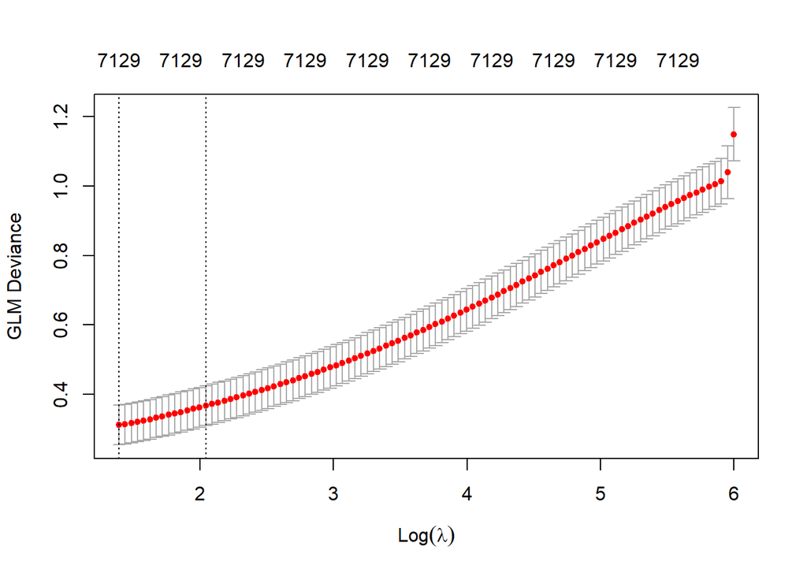

```r
plot(cv.out)
```

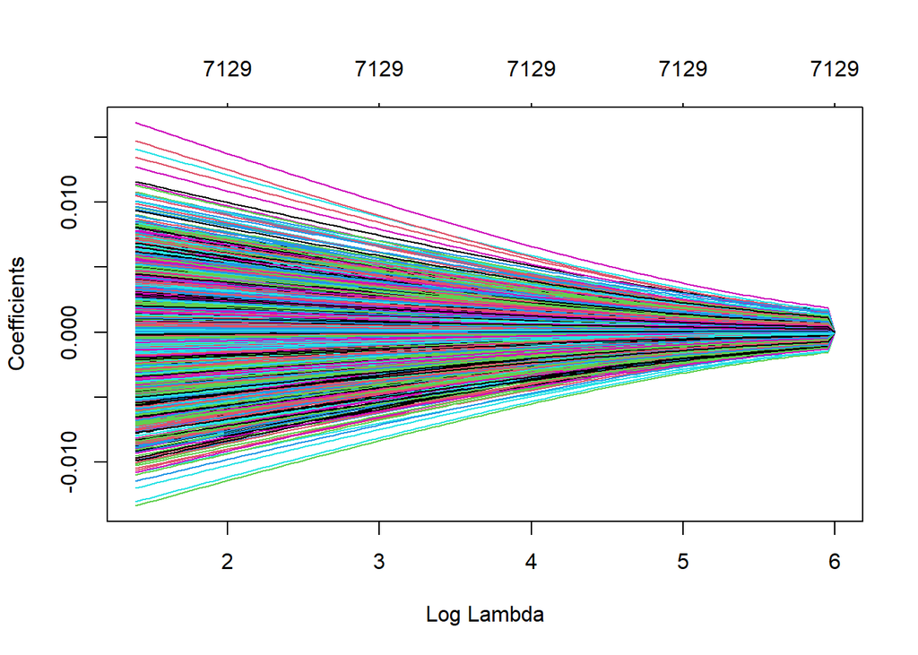

```r
fit_plot <- cv.out$glmnet.fit
plot(fit_plot, xvar="lambda")
```

```r
bestLambda_ridge_reg = cv.out$lambda.min
ridge.pred = as.numeric(predict(ridge.mod, s=bestLambda_ridge_reg, newx = X.test, type="response")>0.5)
mean((ridge.pred-y.test)^2)
```

```
## [1] 0.1111111
```

We can see that the MSE value is 0.111 which is similar to lasso in the earlier analysis. As we know ridge doesn’t bring the coefficients to zero which means there isn’t a variable selection taking place. However, we can identify some important coefficients using some threshold value and filter out.

Let’s try elastic net by varying the alpha value between 0 and 1

```r
length(y.train)
```

```
## [1] 36
```

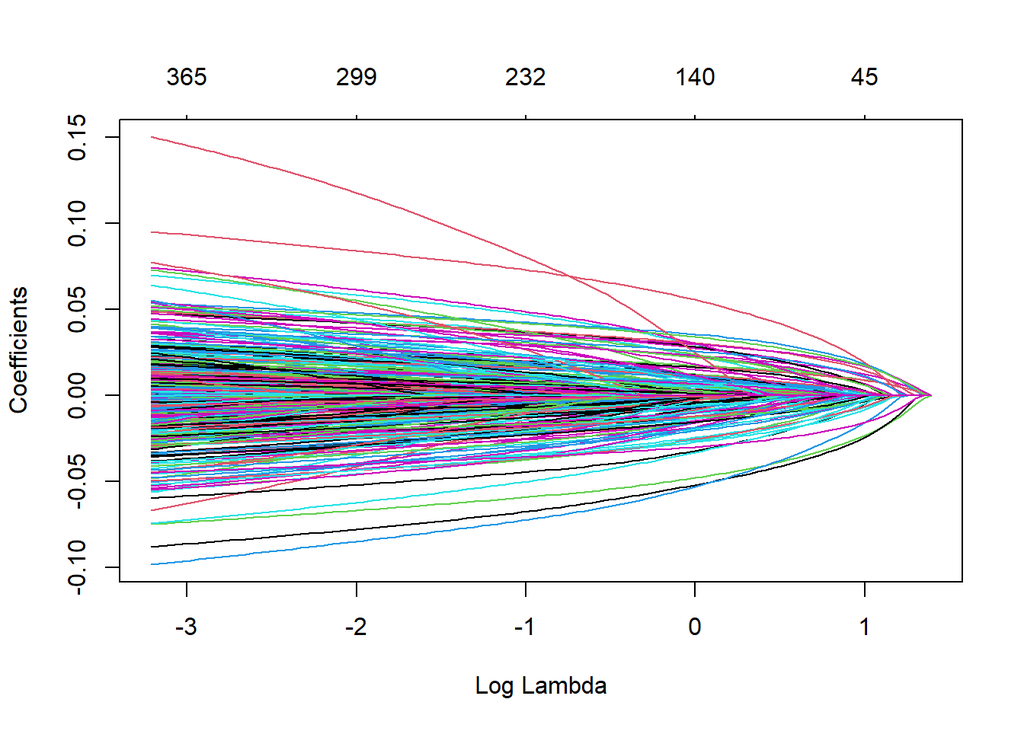

```
## [1] "MSE is  0.00694444444444444  for the alpha value =  0.1"
## [1] "The number of correctly classified items:  33"
```

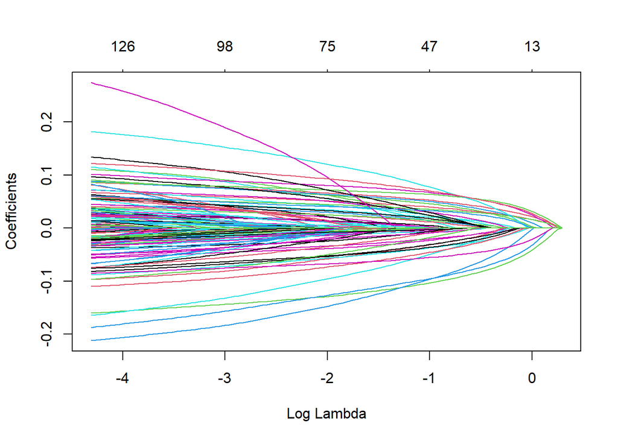

```
## [1] "MSE is  0.00694444444444444  for the alpha value =  0.3"
## [1] "The number of correctly classified items:  33"
```

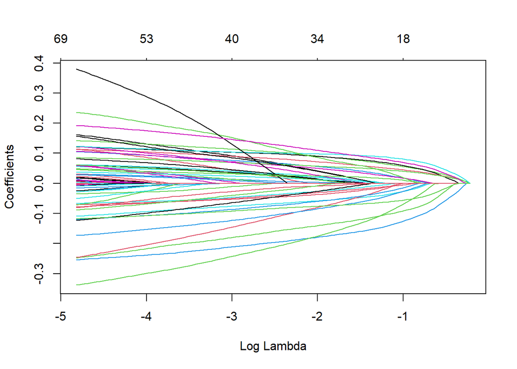

```
## [1] "MSE is  0.00694444444444444  for the alpha value =  0.5"
## [1] "The number of correctly classified items:  33"
```

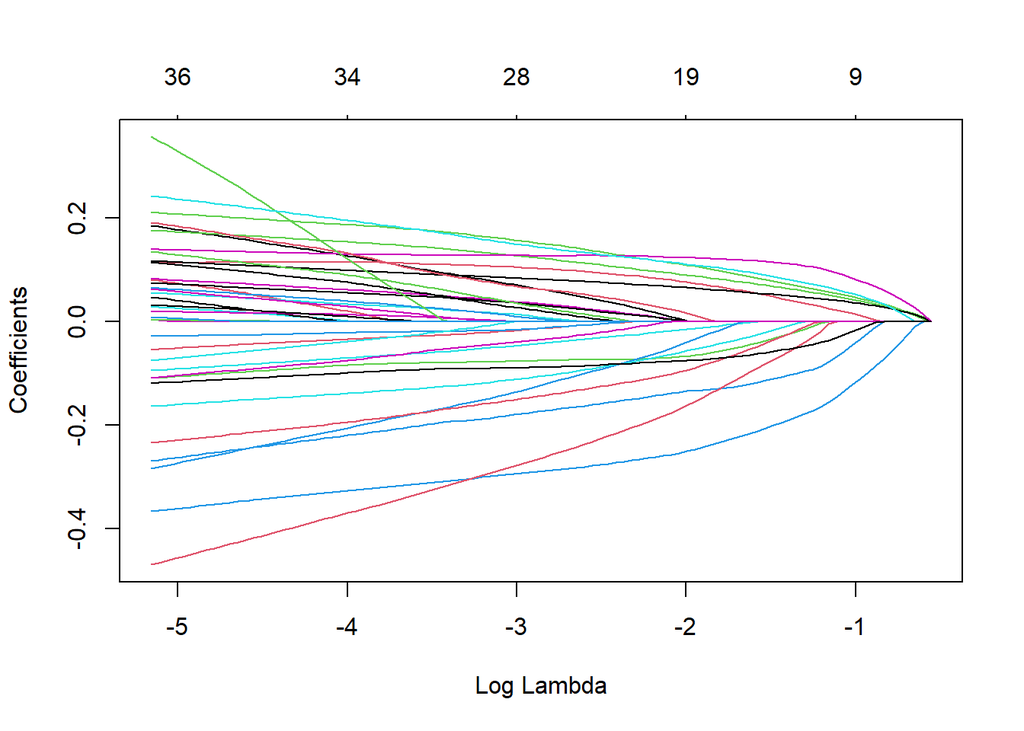

```
## [1] "MSE is  0.00694444444444444  for the alpha value =  0.7"
## [1] "The number of correctly classified items:  33"
```

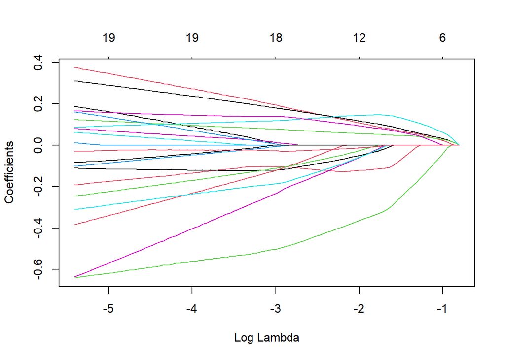

```
## [1] "MSE is  0.0123456790123457  for the alpha value =  0.9"
## [1] "The number of correctly classified items:  32"
```

```r
alpha_arr <- c(0.1,0.3,0.5,0.7,0.9)

for(alpha in alpha_arr){
  elastic.mod = glmnet(X.train, y.train, alpha=alpha, family="binomial")
  cv.out <- cv.glmnet(X.train, y.train, alpha=alpha, family="binomial")

  plot(cv.out$glmnet.fit, xvar="lambda")

  bestLambda_elastic_reg = cv.out$lambda.min
  elastic.pred = as.numeric(predict(elastic.mod, s=bestLambda_elastic_reg, newx = X.test, type="response")>0.5)
  print(paste("MSE is ",mean(elastic.pred-y.test)^2," for the alpha value = ",alpha))

  print(paste("The number of correctly classified items: ",36-sum(as.numeric(abs(elastic.pred-y.test)))))

}
```

```r
acc_logistic <- 33/36
```

## Tree-based algorithms

We use tree based algorithms and compare trees, bagging and random forest using the Golub dataset and analyze its results

```r
set.seed(2)

n = nrow(X)
# Split data into train and test sets
train_rows <- sample(1:n, n/2)
X.train <- X[train_rows, ]
X.test <- X[-train_rows, ]

y.train <- y[train_rows]
y.test <- y[-train_rows]

dim(X.train)
```

```
## [1]   36 7129
```

let’s go ahead and do the test and train dataset split. We can also convert the vectors into dataframes.

```r
set.seed(2)
main.df = data.frame(X,y)
main.df$y <- as.factor(main.df$y)
train.df <- main.df[train_rows, ]
test.df <- main.df[-train_rows, ]
```

We now train the tree with the train dataset. There aren’t many branches due to sample selection and less number of observations

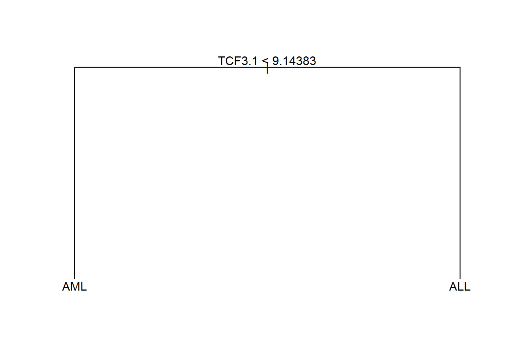

```r
tree.mod = tree(train.df$y~., train.df)

plot(tree.mod)
text(tree.mod, pretty = 0)
```

```r
tree.mod
```

```
## node), split, n, deviance, yval, (yprob)
##       * denotes terminal node
##
## 1) root 36 45.83 ALL ( 0.6667 0.3333 )
##   2) TCF3.1 < 9.14383 12  0.00 AML ( 0.0000 1.0000 ) *
##   3) TCF3.1 > 9.14383 24  0.00 ALL ( 1.0000 0.0000 ) *
```

```r
tree.pred = predict(tree.mod, test.df, type="class")

confusion_mat <- table(test.df$y, tree.pred)
confusion_mat
```

```
##      tree.pred
##       ALL AML
##   ALL  20   3
##   AML   2  11
```

Based on the above confusion matrix the accuracy will be

```r
accuracy <- sum(diag(confusion_mat))/sum(confusion_mat)
accuracy
```

```
## [1] 0.8611111
```

Next, we consider whether pruning the tree might lead to improved results. The function cv.tree() performs cross-validation in order to determine the optimal level of tree complexity; cost complexity pruning is used in order to select a sequence of trees for consideration. We use the argument FUN = prune.misclass in order to indicate that we want the classification error rate as our cost function to guide the cross-validation and pruning process, rather than the default for the cv.tree() function, which is deviance. The cv.tree() function reports the number of terminal nodes of each tree considered (size) as well as the corresponding error rate and the value of the cost-complexity parameter used

```r
prune.mod = cv.tree(tree.mod, FUN=prune.misclass)
prune.mod
```

```
## $size
## [1] 2 1
##
## $dev
## [1]  2 12
##
## $k
## [1] -Inf   12
##
## $method
## [1] "misclass"
##
## attr(,"class")
## [1] "prune"         "tree.sequence"
```

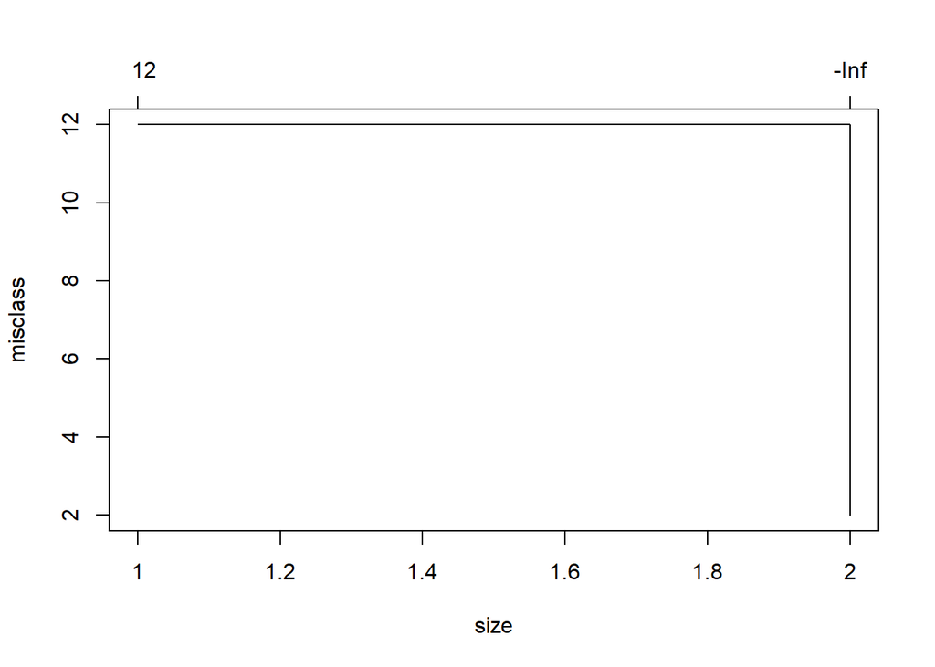

```r
plot(prune.mod)
```

From the above plot we can identify that we have to set the parameter best = 2

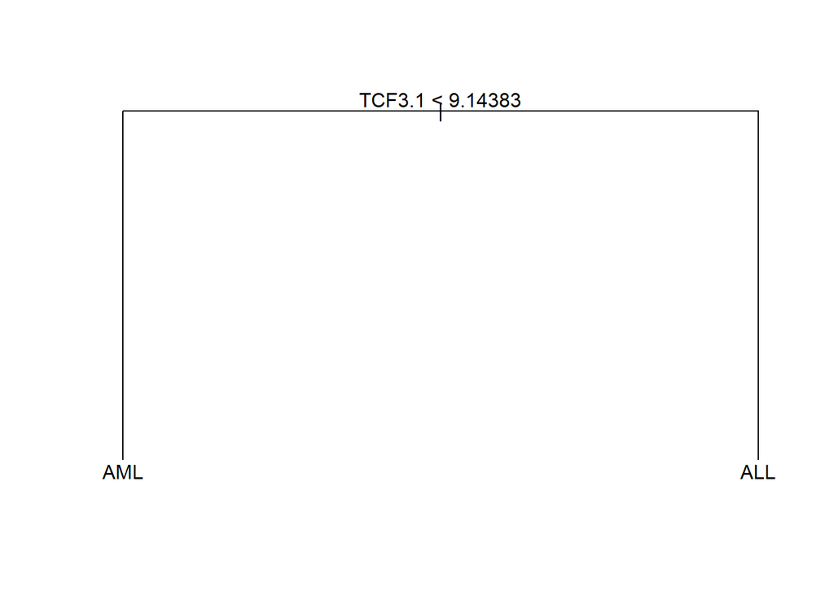

```r
prune_r.mod = prune.misclass(tree.mod, best=2)
plot(prune_r.mod)
text(prune_r.mod, pretty=0)
```

```r
prune.pred = predict(prune_r.mod, test.df, type="class")
with(test.df, table(prune.pred, train.df$y))
```

```
##
## prune.pred ALL AML
##        ALL  15   7
##        AML   9   5
```

```r
confusion_prune <- table(test.df$y, prune.pred)
confusion_prune
```

```
##      prune.pred
##       ALL AML
##   ALL  20   3
##   AML   2  11
```

```r
accuracy <- sum(diag(confusion_prune)) / sum(confusion_prune)
accuracy
```

```
## [1] 0.8611111
```

This validates our earlier hypothesis that this would not lead to an improvement due to the nature of the data. The accuracy does not improve at all. It remains the same at 0.8611

Ensemble learning is an ML technique which combines several learning methods in order to produce one optimal model. In bagging each model is independently constructed using using a bootstrap sample of the dataset. Bagging helps reduce variance and by extension prevent overfitting. We can take the value of mtry as 7129 as it is the number of predictors for this dataset. Let the number of trees be 500 by default,

```r
set.seed(2)
bagging.mod <- randomForest(train.df$y~., data=train.df, mtry = 7129, importance = TRUE)

bagging.mod
```

```
##
## Call:
##  randomForest(formula = train.df$y ~ ., data = train.df, mtry = 7129,      importance = TRUE)
##                Type of random forest: classification
##                      Number of trees: 500
## No. of variables tried at each split: 7129
##
##         OOB estimate of  error rate: 5.56%
## Confusion matrix:
##     ALL AML class.error
## ALL  23   1  0.04166667
## AML   1  11  0.08333333
```

```r
bagging.pred = predict(bagging.mod, newdata=test.df)

confusion_bagging <- table(test.df$y, bagging.pred)
confusion_bagging
```

```
##      bagging.pred
##       ALL AML
##   ALL  23   0
##   AML   2  11
```

Now let’s calculate the accuracy

```r
bagging_acc <- sum(diag(confusion_bagging)) / sum(confusion_bagging)
bagging_acc
```

```
## [1] 0.9444444
```

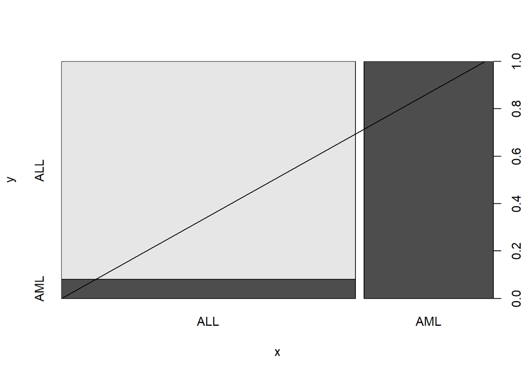

```r
plot(bagging.pred, test.df$y)
abline(0,1)
```

Whenever a split is considered in random forest, a random sample of m predictors are chosen. This is the reason behind the naming of random forest. We chose the mtry value as the square root of p. Hence mtry = 84. We also use tuneRF to determine the best mtry.

It uses OOB error estimate to find the optimal mtry.

```r
set.seed(2)
res <- tuneRF(train.df, train.df$y, stepFactor = 1.5)
```

```
## mtry = 84  OOB error = 8.33%
## Searching left ...
## mtry = 56    OOB error = 13.89%
## -0.6666667 0.05
## Searching right ...
## mtry = 126   OOB error = 16.67%
## -1 0.05
```

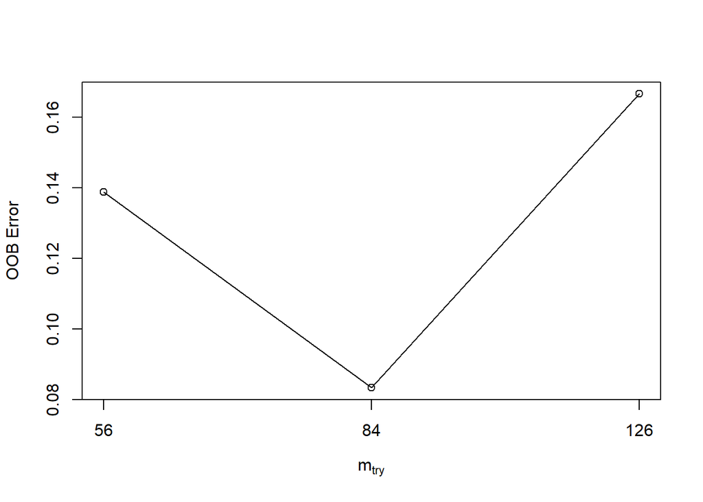

```r
res
```

```
##         mtry   OOBError
## 56.OOB    56 0.13888889
## 84.OOB    84 0.08333333
## 126.OOB  126 0.16666667
```

In this case we observe the optimal m_try at 84

```r
set.seed(2)
rf.mod = randomForest(train.df$y~., data=train.df, mtry=84, importance=TRUE)

rf.mod
```

```
##
## Call:
##  randomForest(formula = train.df$y ~ ., data = train.df, mtry = 84,      importance = TRUE)
##                Type of random forest: classification
##                      Number of trees: 500
## No. of variables tried at each split: 84
##
##         OOB estimate of  error rate: 11.11%
## Confusion matrix:
##     ALL AML class.error
## ALL  23   1  0.04166667
## AML   3   9  0.25000000
```

```r
rf.pred = predict(rf.mod, newdata=test.df, type="class")

confusion_mat <- table(rf.pred, test.df$y)
confusion_mat
```

```
##
## rf.pred ALL AML
##     ALL  23   4
##     AML   0   9
```

Calculating accuracy

```r
accuracy <- sum(diag(confusion_mat)) / sum(confusion_mat)
accuracy
```

```
## [1] 0.8888889
```

Now to compare bagging with random forest over a range of ntrees. Just like previously mtry would be equal to number of predictors to perform bagging and 126 for random forest.

```r
ntreeset = seq(10, 610, by=200)
acc.bag = rep(0,length(ntreeset));acc.rf = rep(0,length(ntreeset))

for(i in 1:length(ntreeset)){
  nt = ntreeset[i]
  bag.mod <- randomForest(train.df$y~., data=train.df, mtry=7129, ntree=nt, importance=TRUE)
  bag.pred = predict(bag.mod, newdata=test.df)
  confusion_bag <- table(test.df$y, bag.pred)
  acc.bag[i] <- sum(diag(confusion_bag)) / sum(confusion_bag)
  rf.mod = randomForest(train.df$y~., data=train.df, mtry=126, ntree = nt, importance=TRUE)
  rf.pred = predict(rf.mod, newdata=test.df, type="class")
  confusion_rf <- table(test.df$y, rf.pred)
  acc.rf[i] <- sum(diag(confusion_rf)) / sum(confusion_rf)
}
```

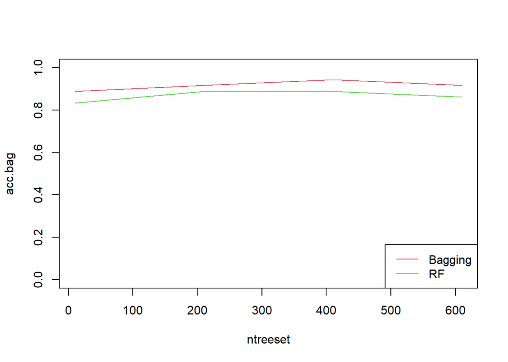

```r
plot(ntreeset, acc.bag, type="l", col=2, ylim=c(0,1))
lines(ntreeset, acc.rf, col=3)
legend("bottomright", c("Bagging", "RF"), col=c(2,3), lty=c(1,1))
```

We plot the accuracy obtained at each iteration. From the plot we can see that bagging starts low and achieves a steady accuracy of 90%. Whereas RF is not worse but is still lesser than the bagging. Overall Bagging performs better than Random Forest in this case.

```r
ntreeset = seq(10,610,by=200)
acc.bag = rep(0, length(ntreeset))
acc.rf1 = rep(0, length(ntreeset))
acc.rf2 = rep(0, length(ntreeset))
acc.rf3 = rep(0, length(ntreeset))

for(i in 1:length(ntreeset)){

  nt = ntreeset[i]

  print("Start")
  bag.mod = randomForest(train.df$y~., data=train.df,mtry=7129,ntree=nt)
  bag.pred = predict(bag.mod, newdata=test.df)
  confusion_bag <- table(test.df$y, bag.pred)
  acc.bag[i] <- sum(diag(confusion_bag)) / sum(confusion_bag)
  print("After bag")

  rf1.mod = randomForest(train.df$y~., data=train.df, mtry=84, ntree=nt)
  rf1.pred = predict(rf1.mod, newdata=test.df)
  confusion_rf1 <- table(test.df$y, rf1.pred)
  acc.rf1[i] <- sum(diag(confusion_rf1)) / sum(confusion_rf1)
  print("After rf1")

  rf2.mod = randomForest(train.df$y~., data=train.df, mtry=126, ntree=nt)
  rf2.pred = predict(rf2.mod, newdata=test.df)
  confusion_rf2 <- table(test.df$y, rf2.pred)
  acc.rf2[i] <- sum(diag(confusion_rf2)) / sum(confusion_rf2)
  print("After rf2")

  rf3.mod = randomForest(train.df$y~., data=train.df, mtry=84, ntree=nt)
  rf3.pred = predict(rf3.mod, newdata=test.df)
  confusion_rf3 <- table(test.df$y, rf3.pred)
  acc.rf3[i] <- sum(diag(confusion_rf3)) / sum(confusion_rf3)
  print("After rf3")

}
```

```
## [1] "Start"
## [1] "After bag"
## [1] "After rf1"
## [1] "After rf2"
## [1] "After rf3"
## [1] "Start"
## [1] "After bag"
## [1] "After rf1"
## [1] "After rf2"
## [1] "After rf3"
## [1] "Start"
## [1] "After bag"
## [1] "After rf1"
## [1] "After rf2"
## [1] "After rf3"
## [1] "Start"
## [1] "After bag"
## [1] "After rf1"
## [1] "After rf2"
## [1] "After rf3"
```

```r
acc.bag
```

```
## [1] 0.8611111 0.9444444 0.9444444 0.9444444
```

```r
acc.rf1
```

```
## [1] 0.9166667 0.8611111 0.8888889 0.8611111
```

```r
acc.rf2
```

```
## [1] 0.8055556 0.8888889 0.8611111 0.8888889
```

```r
acc.rf3
```

```
## [1] 0.8333333 0.8611111 0.8611111 0.8611111
```

```r
ntreeset
```

```
## [1]  10 210 410 610
```

Let’s plot the values

[figure not shown]

```r
plot(ntreeset, acc.bag, type="l", col=2, ylim=c(0,1))
lines(ntreeset, acc.rf1, col=3)
lines(ntreeset, acc.rf2, col=4)
lines(ntreeset, acc.rf3, col=5)

legend("bottomright", c("Bagging", "RF (m=84)", "RF (m=126)", "RF (m=189)"), col=c(2,3,4,5), lty=c(1,1,1,1))
```

To conclude, decision trees work well for the classification of high dimensional data but is not a good predictor due to increased variance. Decision trees are actually faster than bagging or random forest. They can be used for EDA but not so ideal for prediction.

Bagging is a bit more complicated due to the high volume of ‘p’ variables. It had the best accuracy out of the four as per the above plot.

The trees in RF are more independent of each other than bagging, making it suitable for predictive analysis. The dataset however has high number of variables compared to the number of observations which leads to a high variance problem. The reason is because bagging is used as a solution to high variance problem.

## SVM

[output not shown]

```r
svm_model_1 = svm(y~., data = traindata , kernel = "radial", gamma = 1, cost = 1)
svm_model_2 = svm(y~., data = traindata , kernel = "linear",  cost = 0.1)
svm_model_3 = svm(y~., data = traindata , kernel = "polynomial", gamma = 1, cost = 10)
```

```r
testdata = data.frame(x  = X.test, y = as.factor(y.test))
confusion_mtrx_1 <- table(predict(svm_model_1, newdata = testdata), y.test)
confusion_mtrx_2 <- table(predict(svm_model_2, newdata = testdata), y.test)
confusion_mtrx_3 <- table(predict(svm_model_3, newdata = testdata), y.test)
model_1_accuracy = sum(diag(confusion_mtrx_1))/sum(confusion_mtrx_1)
model_2_accuracy = sum(diag(confusion_mtrx_2))/sum(confusion_mtrx_2)
model_3_accuracy = sum(diag(confusion_mtrx_3))/sum(confusion_mtrx_3)
accuracy <- c(model_1_accuracy,model_2_accuracy,model_3_accuracy)
print(accuracy)
```

```
## [1] 0.7777778 0.9444444 0.7777778
```

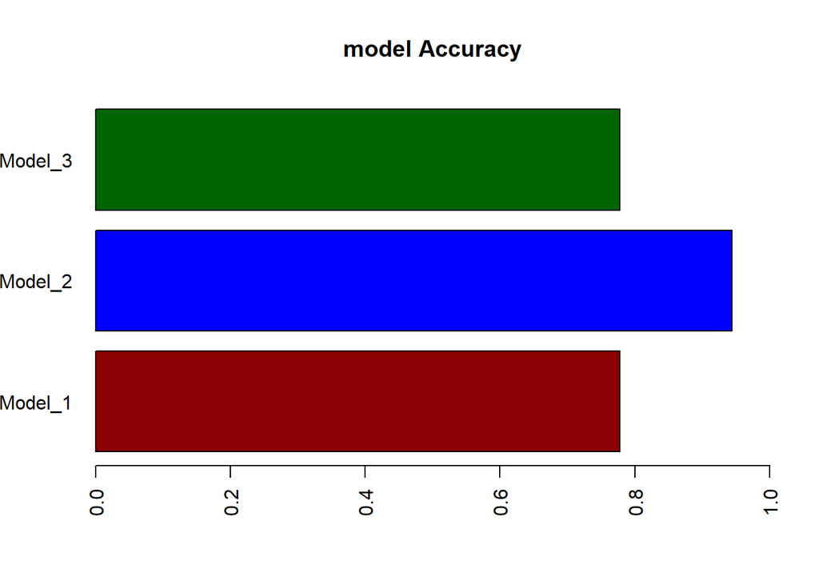

```r
barplot(accuracy, main="model Accuracy", horiz=TRUE, xlim = range(0, 1), col=c("darkred","blue","darkgreen"), names.arg=c("Model_1", "Model_2", "Model_3"),las = 2, cex.names=1)
```

```r
# Extract the best model using tune() function
all_moddels_1 <-  tune(svm, y~., data = traindata, kernel = "radial",ranges = list(cost = c(0.1,1,5,10)))
all_moddels_2 <-  tune(svm, y~., data = traindata, kernel = "linear",ranges = list(cost = c(0.1,1,5,10)))
all_moddels_3 <-  tune(svm, y~., data = traindata, kernel = "polynomial",ranges = list(cost = c(0.1,1,5,10)))
confusion_mtrx_all_Ms_1 <- table(predict(all_moddels_1$best.model, newdata = testdata), y.test)
confusion_mtrx_all_Ms_2 <- table(predict(all_moddels_2$best.model, newdata = testdata), y.test)
confusion_mtrx_all_Ms_3 <- table(predict(all_moddels_3$best.model, newdata = testdata), y.test)
```

```r
B_model_1_accuracy = sum(diag(confusion_mtrx_all_Ms_1))/sum(confusion_mtrx_all_Ms_1)
B_model_2_accuracy = sum(diag(confusion_mtrx_all_Ms_2))/sum(confusion_mtrx_all_Ms_2)
B_model_3_accuracy = sum(diag(confusion_mtrx_all_Ms_3))/sum(confusion_mtrx_all_Ms_3)
accuracy <- c(B_model_1_accuracy,B_model_2_accuracy,B_model_3_accuracy)
print(accuracy)
```

```
## [1] 0.8611111 0.9444444 0.6388889
```

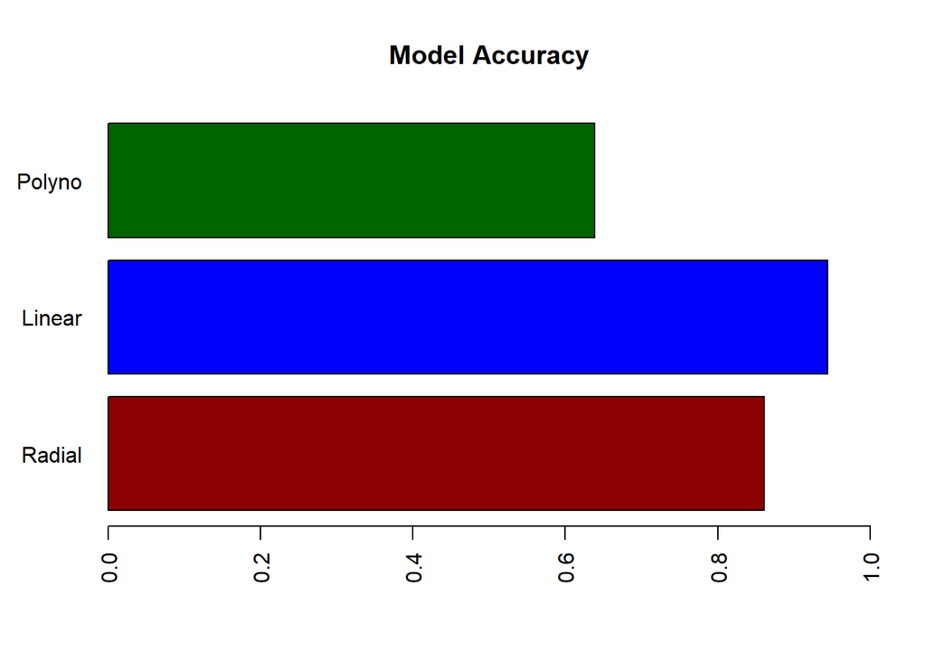

```r
barplot(accuracy, main="Model Accuracy", horiz=TRUE, xlim = range(0, 1), col=c("darkred","blue", "darkgreen"), names.arg=c("Radial", "Linear", "Polyno"),las = 2, cex.names=1)
```

```r
print(all_moddels_1$best.model)
```

```
##
## Call:
## best.tune(method = svm, train.x = y ~ ., data = traindata, ranges = list(cost = c(0.1,
##     1, 5, 10)), kernel = "radial")
##
##
## Parameters:
##    SVM-Type:  C-classification
##  SVM-Kernel:  radial
##        cost:  5
##
## Number of Support Vectors:  36
```

```r
print(all_moddels_2$best.model)
```

```
##
## Call:
## best.tune(method = svm, train.x = y ~ ., data = traindata, ranges = list(cost = c(0.1,
##     1, 5, 10)), kernel = "linear")
##
##
## Parameters:
##    SVM-Type:  C-classification
##  SVM-Kernel:  linear
##        cost:  0.1
##
## Number of Support Vectors:  31
```

```r
print(all_moddels_3$best.model)
```

```
##
## Call:
## best.tune(method = svm, train.x = y ~ ., data = traindata, ranges = list(cost = c(0.1,
##     1, 5, 10)), kernel = "polynomial")
##
##
## Parameters:
##    SVM-Type:  C-classification
##  SVM-Kernel:  polynomial
##        cost:  0.1
##      degree:  3
##      coef.0:  0
##
## Number of Support Vectors:  36
```

[output not shown]

## Conclusion

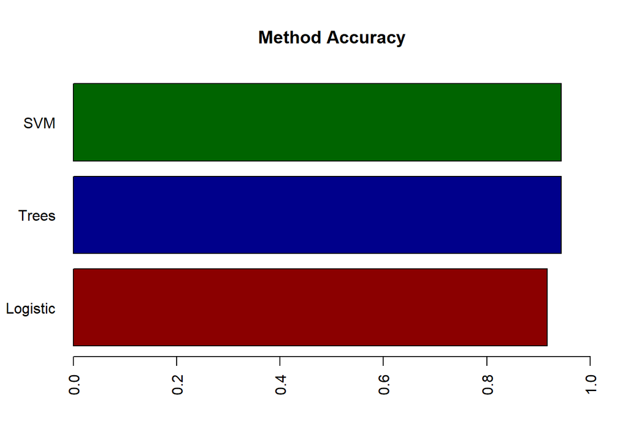

```r
accuracies <- c(acc_logistic ,bagging_acc,B_model_2_accuracy)
barplot(accuracies, main="Method Accuracy", horiz=TRUE, xlim = range(0, 1), col=c("darkred","darkblue", "darkgreen"), names.arg=c("Logistic", "Trees", "SVM"),las = 2, cex.names=1)
```

By combining the accuracies obtained from the different models on our test dataset the below accuracies are obtained,

```r
print(accuracies)
```

```
## [1] 0.9166667 0.9444444 0.9444444
```

Logistic regression with ElasticNet regularization: 91.667% Bagging (Trees) : 94.44% SVM (Linear Kernel): 94.44%